# Predictors of Asthma-Related 30-Day Hospital Readmission

Nearest-Neighbor Propensity Score Matched Cohort Analysis

Umesh Singh umesmail@gmail.com

June 18, 2026

R Markdown analysis report

# Asthma propensity score matching workflow

This is a reanalysis using propensity score matching (PSM) of the [original study](https://pubmed.ncbi.nlm.nih.gov/30053594/) published in Journal of Allergy and Clinical Immunology in Practice.  
The original study was a retrospective observational study. So even with multivariable Cox adjustment, patients with rhinitis may differ from patients without rhinitis in ways that are not fully captured in the data. That could include disease severity, outpatient treatment, adherence, or access to care.  
From a methodological critique, the original paper’s multivariable Cox model is a solid primary analysis for observational survival data, but the causal interpretation is still limited by residual confounding, exposure misclassification, and single-center data. Propensity score matching improves comparability on observed covariates, although it does not solve unmeasured confounding and it may reduce sample size.  
Because patients with chronic rhinitis may systematically differ from those without regarding baseline demographics or severity of illness, PSM mimics a randomized controlled trial by balancing these baseline covariates.

# Analysis

## Study Overview

**Definitions: Treatment, Outcome, and Population**

- The Population (N=4,754): Patients **hospitalized with a primary discharge diagnosis of asthma** based on ICD-10-CM codes.
- The Exposure/Treatment (Z): **Comorbid chronic allergic rhinitis (AR)** identified via ICD-10-CM codes.
  - Group 1 (Exposed): Asthma patients **with comorbid AR**.
  - Group 0 (Control): Asthma patients **without AR diagnosis**.
- The Primary Outcome (Y): **30-day asthma-related hospital readmission** from the index discharge date.

### Local cohort snapshot

| Metric | Value |
| --- | --- |
| Analytic rows | 4754 |
| AR exposed (YES) | 156 |
| AR controls (NO) | 4598 |
| Readmission events | 857 |
| Index admissions | 3897 |

### Variables

| Analysis_Name | Local_Source |
| --- | --- |
| ID | ID |
| AR1 | AR -&gt; YES/NO |
| GENDER | Gender |
| RACE | race |
| ARR1 | ARR -&gt; YES/NO |
| DM1 | DM -&gt; YES/NO |
| HTN1 | HTN -&gt; YES/NO |
| OBESITY1 | Obesity -&gt; YES/NO |
| TOB1 | TOB -&gt; YES/NO |
| AGE | Age |

[output cut: 10 more lines]

## Data Preparation

This tab shows the conversion from the local CSV into the analytic dataset used by the matching and survival models.

### Importance of this step

1. a clean patient-level asthma cohort,
2. binary YES/NO exposure and comorbidity flags,
3. event-time variables that can feed directly into `Surv(...)`.

The local file already contains patient-level rows, but the indicator variables need to be harmonized into a consistent analytic format and one stray header-like row must be removed.

### Data preparation code

```r
asthma_prepped <- prep_asthma("asthma.csv")

cat("Rows after cleaning:", nrow(asthma_prepped), "\n")
```

```
## Rows after cleaning: 4754
```

```r
cat("Columns after harmonization:", ncol(asthma_prepped), "\n")
```

```
## Columns after harmonization: 60
```

### Prepared data preview

| ID | AR1 | GENDER | RACE | ARR1 | DM1 | HTN1 | OBESITY1 | TOB1 | AGE | READM | COUNT | LASTDIS | CENSOR |
| --- | --- | --- | --- | --- | --- | --- | --- | --- | --- | --- | --- | --- | --- |
| 1 | NO | Female | AA | NO | YES | YES | NO | NO | 34 | Index | 1 | 1081 | 0 |
| 2 | NO | Male | AA | NO | NO | NO | NO | NO | 38 | Index | 1 | 997 | 0 |
| 9 | NO | Male | White | NO | NO | YES | NO | NO | 58 | Index | 1 | 1553 | 0 |
| 11 | NO | Female | AA | NO | NO | NO | NO | NO | 31 | Index | 1 | 721 | 0 |
| 13 | NO | Female | White | YES | NO | YES | NO | YES | 71 | &lt;=30d | 3 | 11 | 1 |
| 14 | NO | Female | White | NO | NO | YES | NO | NO | 52 | Index | 1 | 810 | 0 |
| 15 | NO | Female | White | NO | NO | NO | NO | YES | 50 | &lt;=30d | 2 | 0 | 1 |
| 16 | NO | Male | White | NO | NO | NO | NO | NO | 61 | Index | 1 | 1405 | 0 |
| 18 | NO | Female | AA | NO | NO | YES | YES | NO | 62 | &lt;=30d | 3 | 3 | 1 |
| 19 | NO | Female | AA | NO | NO | NO | NO | YES | 31 | Index | 1 | 273 | 0 |

[output cut: 2 more lines]

## Matching Workflow

This section covers the design-stage analysis. The propensity score is estimated by logistic regression inside `MatchIt`, and then a nearest-neighbor matched sample is formed.

### Nearest-neighbor matching

This report uses nearest-neighbor matching with a one-to-one match ratio. The propensity score model includes baseline comorbidities, demographics, and age.

Nearest-Neighbor Matching Specification

Design choices used to build the matched cohort

| Component | Value |
| --- | --- |
| Treatment indicator | AR1 (YES vs NO) |
| Propensity score model | AR1 ~ ARR1 + DM1 + HTN1 + GENDER + OBESITY1 + TOB1 + AGE |
| Matching method | Nearest-neighbor matching |
| Match ratio | 1 treated : 1 control |

|  | Model statement |
| --- | --- |
| MatchIt call | matchit(AR1 ~ ARR1 + DM1 + HTN1 + GENDER + OBESITY1 + TOB1 + AGE, data = asthma, method = "nearest") |

### Sample sizes after matching

This table shows the matched and unmatched counts for the nearest-neighbor design.

Sample Sizes Before and After Matching

| Design | Group | Control | Treated |
| --- | --- | --- | --- |
| Nearest neighbor | All (ESS) | 4,598 | 156 |
| Nearest neighbor | All | 4,598 | 156 |
| Nearest neighbor | Matched (ESS) | 156 | 156 |
| Nearest neighbor | Matched | 156 | 156 |
| Nearest neighbor | Unmatched | 4,442 | 0 |
| Nearest neighbor | Discarded | 0 | 0 |

`Matched` is the literal number of observations that were retained in the matched sample. `Matched (ESS)` means the **effective sample size**, which adjusts the matched sample count for weighting. In simple 1:1 nearest-neighbor matching without extra weighting, the effective sample size is often the same as the raw matched count, which is why both rows are `156` here for treated and control patients.

## Balance Diagnostics

This tab explains the key design question after matching: did the treated and control groups become more comparable on observed covariates?  
Propensity score matching is only useful if it actually reduces imbalance. This report shows balance summaries from `summary(matchit_object)` and adds love plots through `cobalt` so the covariate shifts are easier to read visually.

### Standardized mean differences

Standardized Mean Differences

Comparison of imbalance before and after nearest-neighbor matching

| Covariate | Before matching | After matching | Design |
| --- | --- | --- | --- |
| Propensity score | 0.491 | 0.007 | Nearest neighbor |
| ARR1_YES | 0.096 | −0.013 | Nearest neighbor |
| DM1_YES | 0.123 | 0.000 | Nearest neighbor |
| HTN1_YES | 0.232 | −0.026 | Nearest neighbor |
| GENDER_Male | −0.082 | −0.038 | Nearest neighbor |
| OBESITY1_YES | 0.190 | 0.026 | Nearest neighbor |
| TOB1_YES | 0.042 | −0.006 | Nearest neighbor |
| Age | −0.210 | −0.015 | Nearest neighbor |

### Full balance summary: all data

Balance Summary for All Data

Raw covariate differences before matching

| Covariate | Mean treated | Mean control | Std. mean diff. | Var. ratio | eCDF mean | eCDF max | Std. pair dist. |
| --- | --- | --- | --- | --- | --- | --- | --- |
| Propensity score | 0.066 | 0.032 | 0.491 | 5.647 | 0.200 | 0.310 | — |
| ARR1: No | 0.865 | 0.962 | −0.282 | — | 0.096 | 0.096 | — |
| ARR1: Yes | 0.135 | 0.038 | 0.282 | — | 0.096 | 0.096 | — |
| Diabetes: No | 0.788 | 0.912 | −0.302 | — | 0.123 | 0.123 | — |
| Diabetes: Yes | 0.212 | 0.088 | 0.302 | — | 0.123 | 0.123 | — |
| Hypertension: No | 0.571 | 0.803 | −0.469 | — | 0.232 | 0.232 | — |
| Hypertension: Yes | 0.429 | 0.197 | 0.469 | — | 0.232 | 0.232 | — |
| Gender: Female | 0.705 | 0.623 | 0.181 | — | 0.082 | 0.082 | — |
| Gender: Male | 0.295 | 0.377 | −0.181 | — | 0.082 | 0.082 | — |
| Obesity: No | 0.737 | 0.927 | −0.431 | — | 0.190 | 0.190 | — |
| Obesity: Yes | 0.263 | 0.073 | 0.431 | — | 0.190 | 0.190 | — |
| Tobacco use: No | 0.686 | 0.728 | −0.091 | — | 0.042 | 0.042 | — |
| Tobacco use: Yes | 0.314 | 0.272 | 0.091 | — | 0.042 | 0.042 | — |
| Age | 46.519 | 49.853 | −0.210 | 0.815 | 0.034 | 0.099 | — |

### Full balance summary: matched data

Balance Summary for Matched Data

Covariate differences after nearest-neighbor matching

| Covariate | Mean treated | Mean control | Std. mean diff. | Var. ratio | eCDF mean | eCDF max | Std. pair dist. |
| --- | --- | --- | --- | --- | --- | --- | --- |
| Propensity score | 0.066 | 0.066 | 0.007 | 1.035 | 0.000 | 0.019 | 0.017 |
| ARR1: No | 0.865 | 0.853 | 0.038 | — | 0.013 | 0.013 | 0.300 |
| ARR1: Yes | 0.135 | 0.147 | −0.038 | — | 0.013 | 0.013 | 0.300 |
| Diabetes: No | 0.788 | 0.788 | 0.000 | — | 0.000 | 0.000 | 0.090 |
| Diabetes: Yes | 0.212 | 0.212 | 0.000 | — | 0.000 | 0.000 | 0.090 |
| Hypertension: No | 0.571 | 0.545 | 0.052 | — | 0.026 | 0.026 | 0.181 |
| Hypertension: Yes | 0.429 | 0.455 | −0.052 | — | 0.026 | 0.026 | 0.181 |
| Gender: Female | 0.705 | 0.667 | 0.084 | — | 0.038 | 0.038 | 0.253 |
| Gender: Male | 0.295 | 0.333 | −0.084 | — | 0.038 | 0.038 | 0.253 |
| Obesity: No | 0.737 | 0.763 | −0.058 | — | 0.026 | 0.026 | 0.204 |
| Obesity: Yes | 0.263 | 0.237 | 0.058 | — | 0.026 | 0.026 | 0.204 |
| Tobacco use: No | 0.686 | 0.679 | 0.014 | — | 0.006 | 0.006 | 0.262 |
| Tobacco use: Yes | 0.314 | 0.321 | −0.014 | — | 0.006 | 0.006 | 0.262 |
| Age | 46.519 | 46.756 | −0.015 | 1.101 | 0.009 | 0.038 | 0.291 |

This matched-data balance table shows that nearest-neighbor matching substantially improved comparability between patients with allergic-rhinitis and those witout allergic-rhinitis. The standardized mean differences are small across all listed covariates, with the largest residual imbalance still under the common `0.10` threshold. For example, diabetes is exactly balanced in the matched sample, tobacco use is very closely balanced, and age differs only minimally between groups. The propensity-score distance is also nearly identical after matching, which is what we want to see if the matched controls are good comparators for the treated patients.

The other diagnostics point in the same direction. Variance ratios are close to `1.0` for the continuous variables, especially age and the propensity score, which suggests that the treated and control groups have similar spread after matching. The eCDF mean and eCDF maximum values are also small, indicating that the overall distributions line up much better after matching than they did before matching. Taken together, these results suggest that the matched cohort is reasonably well balanced on the measured baseline covariates used in the propensity score model.

### Love plot: nearest-neighbor matching

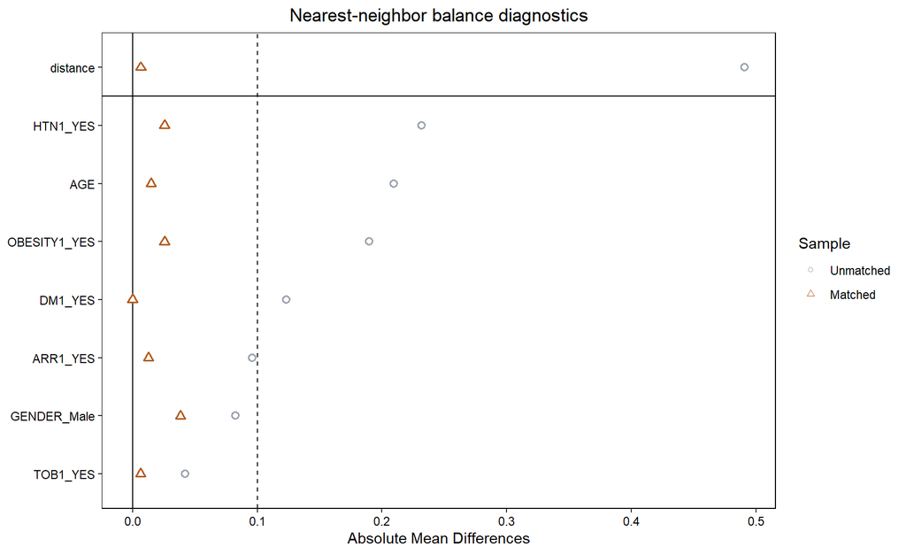

```r
love.plot(
  nearest_match,
  abs = TRUE,
  stats = "mean.diffs",
  threshold = 0.10,
  var.order = "unadjusted",
  colors = c("#9ca3af", "#b35c1e"),
  shapes = c("circle filled", "triangle filled"),
  sample.names = c("Unmatched", "Matched"),
  title = "Nearest-neighbor balance diagnostics"
)
```

The love plot gives the same message in a visual form. Each covariate has two points: the unmatched imbalance and the matched imbalance. Before matching, several variables such as hypertension, obesity, the propensity score itself, and allergic-rhinitis-related comorbidity were meaningfully imbalanced. After matching, the points shift leftward toward zero, and all matched standardized mean differences fall below the `0.10` reference line. That pattern supports the idea that nearest-neighbor matching meaningfully reduced observable confounding and created a more comparable analytic sample for the survival models.

## Survival Models

This section shows downstream outcome analysis after matching.  
It includes both an **Aalen additive hazards model** and a **Cox proportional hazards model.**

### Extracting the matched cohort

```r
cat("Nearest-neighbor matched rows:", nrow(matched_data), "\n")
```

```
## Nearest-neighbor matched rows: 312
```

### Aalen additive hazards models

The `aareg()` model is included as a supplement to Cox regression. This is helpful because the additive hazards model describes the covariate effect on the hazard difference scale rather than the hazard ratio scale. In other words, the Cox model tells us **how many times higher or lower the instantaneous readmission rate** is, while the Aalen model tells us **how much absolute hazard is added over time**. That gives a useful second perspective: instead of only asking whether allergic rhinitis is associated with a relative increase in risk, we can also ask whether it contributes a steadily accumulating excess readmission burden during follow-up.

| term | slope | coef | se_coef | z | p_value | Match |
| --- | --- | --- | --- | --- | --- | --- |
| Intercept | -0.0005 | 0.0001 | 0.0012 | 0.0981 | 0.9218 | Nearest neighbor |
| AGE | 0 | 0 | 0 | -0.3444 | 0.7306 | Nearest neighbor |
| GENDERMale | 0.0077 | 0.0016 | 0.0008 | 1.99 | 0.0466 | Nearest neighbor |
| RACEOther | 0.0107 | 0.0014 | 0.0022 | 0.606 | 0.5445 | Nearest neighbor |
| RACEWhite | -0.0025 | -0.001 | 0.0007 | -1.3729 | 0.1698 | Nearest neighbor |
| AR1YES | 0.0167 | 0.0037 | 0.0008 | 4.8453 | 0 | Nearest neighbor |
| ARR1YES | 0.0267 | 0.0044 | 0.0017 | 2.6285 | 0.0086 | Nearest neighbor |
| DM1YES | -0.0021 | 0.0001 | 0.0012 | 0.117 | 0.9068 | Nearest neighbor |
| HTN1YES | 0.0033 | 0.0005 | 0.001 | 0.4909 | 0.6235 | Nearest neighbor |
| OBESITY1YES | 0.035 | 0.0054 | 0.0015 | 3.7272 | 0.0002 | Nearest neighbor |

[output cut: 1 more lines]

### Aalen coefficient plot for allergic rhinitis

This figure focuses on the AR term so the report highlights the exposure of interest. The solid line is the cumulative coefficient for `AR1YES` across follow-up time, and the dashed lines are approximate 95% confidence bands. An upward-sloping positive curve means that, within the matched cohort, patients with allergic rhinitis accumulate more readmission hazard over time than similar patients without allergic rhinitis. In this plot the curve stays above zero and rises through the 30-day window, which supports a persistent positive association between allergic rhinitis and readmission hazard after matching.

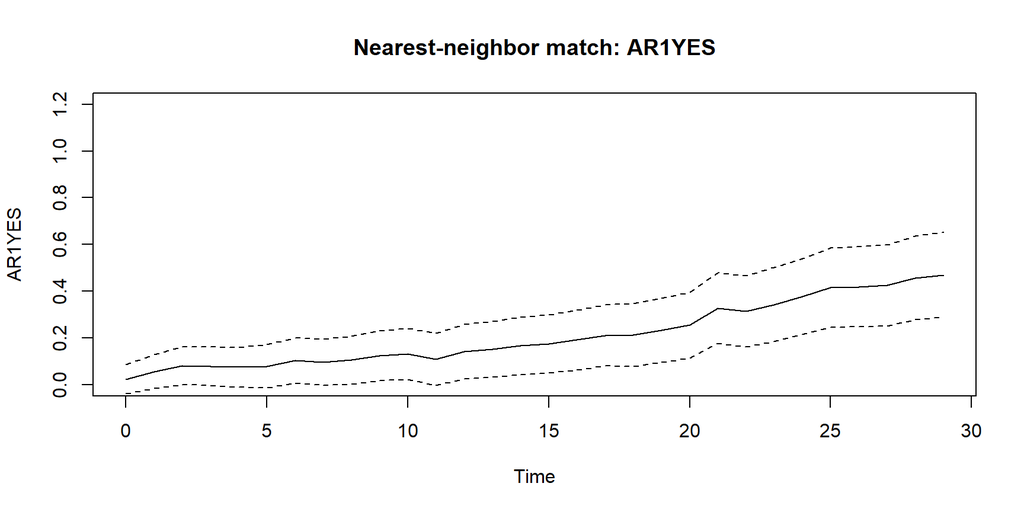

```r
plot(aalen_fit[6], se = TRUE, type = "l", main = "Nearest-neighbor match: AR1YES", ylim = c(0, 1.2))
```

### Cox proportional hazards models

The matched survival models are then estimated using:

```r
Surv(LASTDIS, CENSOR) ~ (AR1 + ARR1 + DM1 + HTN1 + OBESITY1 + TOB1 + RACE) +
  strata(AGEGRP) + cluster(ID)
```

with `ties = "efron"` and `weights = COUNT`.

```r
cox_fit
```

```
## Call:
## coxph(formula = Surv(LASTDIS, CENSOR) ~ AR1 + ARR1 + DM1 + HTN1 +
##     OBESITY1 + TOB1 + RACE + strata(AGEGRP), data = matched_data,
##     weights = COUNT, ties = "efron", singular.ok = TRUE, cluster = ID)
##
##                 coef exp(coef) se(coef) robust se      z        p
## AR1YES       0.79221   2.20828  0.09679   0.20543  3.856 0.000115
## ARR1YES      0.30773   1.36034  0.08140   0.26185  1.175 0.239894
## DM1YES      -0.05525   0.94625  0.09572   0.20530 -0.269 0.787842
## HTN1YES      0.24471   1.27725  0.10810   0.36707  0.667 0.504991
## OBESITY1YES  0.51248   1.66943  0.08924   0.26527  1.932 0.053365
## TOB1YES      0.65915   1.93315  0.06923   0.24844  2.653 0.007976
## RACEOther   -0.08486   0.91864  0.22540   0.54677 -0.155 0.876659
## RACEWhite   -0.22358   0.79965  0.10068   0.25580 -0.874 0.382085
##
## Likelihood ratio test=335  on 8 df, p=< 2.2e-16
## n= 312, number of events= 114
```

Cox Model Results After Nearest-Neighbor Matching

Cluster-robust Cox proportional hazards model

| Covariate | Hazard ratio | Lower 95% CI | Upper 95% CI | P value | Match |
| --- | --- | --- | --- | --- | --- |
| Allergic rhinitis | 2.21 | 1.48 | 3.30 | <0.001 | Nearest neighbor |
| ARR1: YES vs NO | 1.36 | 0.81 | 2.27 | 0.240 | Nearest neighbor |
| Diabetes | 0.95 | 0.63 | 1.42 | 0.788 | Nearest neighbor |
| Hypertension | 1.28 | 0.62 | 2.62 | 0.505 | Nearest neighbor |
| Obesity | 1.67 | 0.99 | 2.81 | 0.053 | Nearest neighbor |
| Tobacco use | 1.93 | 1.19 | 3.15 | 0.008 | Nearest neighbor |
| Race: Other vs AA | 0.92 | 0.32 | 2.68 | 0.877 | Nearest neighbor |
| Race: White vs AA | 0.80 | 0.48 | 1.32 | 0.382 | Nearest neighbor |

This Cox model estimates the association between each covariate and the instantaneous hazard of 30-day readmission after matching. A hazard ratio above `1.0` means a higher readmission hazard, while a hazard ratio below `1.0` means a lower hazard, compared with the reference group, holding the other model terms constant. For example, the hazard ratio for allergic rhinitis is about `2.21`, which means the readmission hazard is estimated to be a little more than two times as high for matched patients with allergic rhinitis as for matched patients without allergic rhinitis.

In this matched cohort, the clearest statistically significant risk factors are allergic rhinitis and tobacco use. Allergic rhinitis has a hazard ratio of `2.21` with a 95% confidence interval of `1.48` to `3.30` and `p < 0.001`, so it remains strongly associated with higher readmission risk after propensity score matching. Tobacco use also remains significant, with a hazard ratio of `1.93`, a 95% confidence interval of `1.19` to `3.15`, and `p = 0.008`, suggesting nearly double the readmission hazard among tobacco users.

## Hazard Ratio Displays

This section uses `rms::cph()` to display hazard ratios graphically and presents the results as a clean forest plot for the matched cohort.

### Forest plot: nearest-neighbor matched cohort

The hazard-ratio plots make it easier to see the direction and relative size of each effect, especially the allergic rhinitis term.

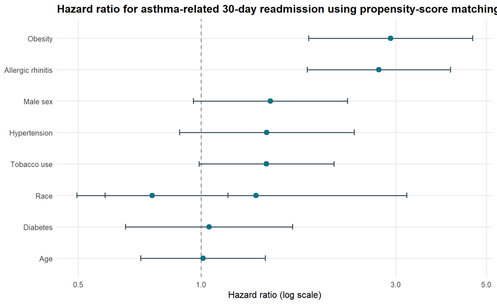

```r
plot_forest(forest_data, "Hazard ratio for asthma-related 30-day readmission using propensity-score matching")
```

This forest plot is a visual summary of the `cph()` model. Points to the right of 1.0 indicate higher hazard, and intervals that stay fully above 1.0 suggest a positive association with readmission in this matched cohort. The allergic rhinitis term is one of the clearest signals in the plot, with an estimated hazard ratio of about `2.72` and a 95% confidence interval from `1.82` to `4.08`. Obesity is also strongly positive at about `2.91` (`1.83` to `4.62`). Tobacco use, male sex, and hypertension trend toward higher hazard, but their intervals are wider and some include or nearly include 1.0, so those estimates are less precise. Age and diabetes are close to the null, and the race comparisons remain imprecise in the matched sample. Because this figure comes from `cph()` rather than the clustered `coxph()` model above, it is best used as a visual effect-size summary alongside, not instead of, the primary Cox table.

## IPTW Comparison

This tab adds an inverse probability of treatment weighting analysis so the report can compare matching and weighting side by side. The IPTW analysis here targets the **average treatment effect in the treated (ATT)**, which makes it a natural complement to nearest-neighbor matching because both approaches focus on estimating the effect of allergic rhinitis among patients who actually had the exposure. In plain language, this means we are asking how allergic rhinitis relates to readmission risk in the asthma patients who actually had allergic rhinitis, compared with similar patients who did not. In other words, IPTW keeps all patients in the analysis but gives more weight to the non-rhinitis patients who look most similar to the rhinitis patients.

### IPTW specification

IPTW Design Specification

ATT weighting used as a sensitivity analysis

| Component | Value |
| --- | --- |
| Target estimand | ATT (average treatment effect in the treated) |
| Propensity score model | AR1 ~ ARR1 + DM1 + HTN1 + GENDER + OBESITY1 + TOB1 + AGE + RACE |
| Weighting rule | Treated = 1; Control = PS / (1 - PS) |
| Weight trimming | Weights truncated at the 1st and 99th percentiles |

### Weight distribution

Summary of IPTW Weights

| Statistic | Weight |
| --- | --- |
| Minimum | 0.007 |
| 1st percentile | 0.007 |
| Median | 0.025 |
| Mean | 0.065 |
| 99th percentile | 1.000 |
| Maximum | 1.000 |

These weights are fairly well behaved after trimming, which is reassuring because extreme weights can make IPTW estimates unstable. Here, the ATT weights remain bounded and do not show the kind of large outliers that would immediately undermine the weighted survival model.

### Effective sample after weighting

Observed and Effective Sample Sizes Under IPTW

| Stage | Control | Treated |
| --- | --- | --- |
| Unadjusted | 4,598.0 | 156.0 |
| Adjusted | 2,113.3 | 156.0 |

The adjusted row shows the effective sample size after weighting rather than a literal matched count. Unlike matching, IPTW keeps the full cohort in the analysis, but it changes each patient’s influence through the weights so that the weighted control group better resembles the treated patients.

### IPTW balance table

Balance Before and After IPTW

Standardized mean differences for the ATT-weighted sample

| Method | Covariate | Type | Before weighting | After weighting |
| --- | --- | --- | --- | --- |
| IPTW (ATT) | ARR1: Yes | Binary | 0.096 | 0.007 |
| IPTW (ATT) | Diabetes: Yes | Binary | 0.123 | 0.007 |
| IPTW (ATT) | Hypertension: Yes | Binary | 0.232 | 0.004 |
| IPTW (ATT) | Gender: Male | Binary | −0.082 | −0.002 |
| IPTW (ATT) | Obesity: Yes | Binary | 0.190 | 0.004 |
| IPTW (ATT) | Tobacco use: Yes | Binary | 0.042 | 0.003 |
| IPTW (ATT) | Age | Contin. | −0.210 | 0.004 |
| IPTW (ATT) | Race: AA | Binary | 0.145 | 0.008 |
| IPTW (ATT) | Race: Other | Binary | −0.008 | −0.001 |
| IPTW (ATT) | Race: White | Binary | −0.137 | −0.006 |

The weighted balance results are strong overall. After ATT weighting, the standardized mean differences for the measured covariates are all close to zero, including age and race, which indicates that the weighted control group now looks much more like the treated group at baseline. This is the main design goal of IPTW.

### Love plot: IPTW

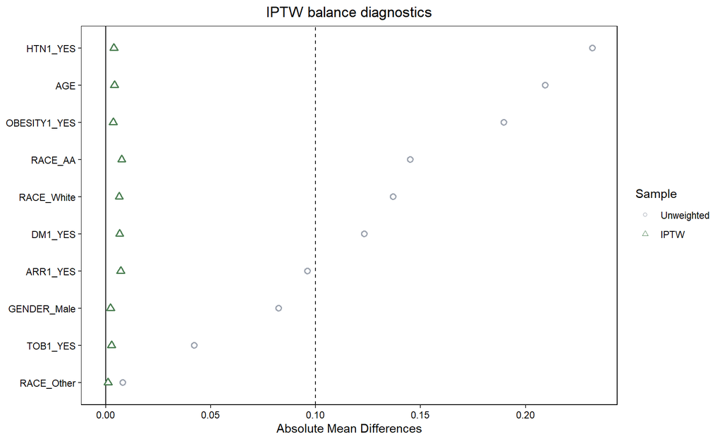

```r
love.plot(
  iptw_formula,
  data = asthma,
  weights = asthma$iptw_att,
  method = "weighting",
  estimand = "ATT",
  abs = TRUE,
  stats = "mean.diffs",
  threshold = 0.10,
  var.order = "unadjusted",
  colors = c("#9ca3af", "#4b7f52"),
  shapes = c("circle filled", "triangle filled"),
  sample.names = c("Unweighted", "IPTW"),
  title = "IPTW balance diagnostics"
)
```

This love plot lets us compare IPTW visually with the earlier matching diagnostics. As in the matching plot, the weighted points move leftward toward zero. Here the residual imbalance is very small across the included covariates, which suggests that the ATT-weighted pseudo-population is well balanced on the measured confounders.

### Weighted Cox model

Weighted Cox Model After IPTW

Cluster-robust Cox model using ATT weights

| Covariate | Hazard ratio | Lower 95% CI | Upper 95% CI | P value | Method |
| --- | --- | --- | --- | --- | --- |
| Allergic rhinitis | 2.91 | 2.29 | 3.69 | <0.001 | IPTW (ATT) |
| ARR1: YES vs NO | 2.02 | 1.41 | 2.90 | <0.001 | IPTW (ATT) |
| Diabetes | 1.08 | 0.74 | 1.59 | 0.682 | IPTW (ATT) |
| Hypertension | 1.20 | 0.80 | 1.80 | 0.377 | IPTW (ATT) |
| Obesity | 2.43 | 1.68 | 3.53 | <0.001 | IPTW (ATT) |
| Tobacco use | 1.24 | 0.91 | 1.70 | 0.176 | IPTW (ATT) |
| Race: Other vs AA | 1.31 | 0.60 | 2.83 | 0.494 | IPTW (ATT) |
| Race: White vs AA | 0.97 | 0.69 | 1.36 | 0.872 | IPTW (ATT) |

### PSM versus IPTW

Comparison of the Allergic Rhinitis Effect

Nearest-neighbor matching versus ATT-weighted IPTW

| Method | Analytic sample | Hazard ratio | Lower 95% CI | Upper 95% CI | P value |
| --- | --- | --- | --- | --- | --- |
| Nearest-neighbor matching | Matched cohort (312 rows) | 2.21 | 1.48 | 3.30 | <0.001 |
| IPTW (ATT) | Weighted full cohort (n = 4,754) | 2.91 | 2.29 | 3.69 | <0.001 |

The comparison table highlights the main takeaway: both methods point in the same direction, and both support a higher readmission hazard among patients with allergic rhinitis. The nearest-neighbor match gives a hazard ratio of about `2.21`, while the ATT-weighted IPTW analysis gives a hazard ratio of about `2.91`. That consistency strengthens confidence that the finding is not an artifact of one specific propensity score implementation, even though the exact magnitude differs across designs.

## Interpretation notes

- In plain language, the propensity score helps us compare patients who look more alike at baseline. That makes the allergic-rhinitis and non-rhinitis groups more similar on measured characteristics such as age, smoking, obesity, and comorbidities before we compare readmission outcomes.
- This does not make the study randomized, but it does make the final comparison cleaner and easier to interpret. It reduces the chance that the observed association is driven mainly by measured baseline differences rather than the exposure itself.
- Relative to the original study’s multivariable Cox regression alone, propensity score matching adds a design step before outcome modeling. It makes the allergic-rhinitis and non-rhinitis groups more comparable on measured baseline covariates, which reduces model dependence and strengthens the covariate-adjusted comparison.
- Propensity score matching does not eliminate unmeasured confounding, and it can reduce precision because unmatched patients are dropped. That means it should be viewed as a complement to, not a replacement for, thoughtful regression adjustment.
- The matched-survival sections use three complementary model families: `aareg()`, `coxph()`, and `cph()`.